# Analyzing single cell perturbational response datasets with perturbLM

perturbLM is a lightweight package for assessing the effects of perturbations on single cell omics datasets. Here, we’ll demonstrate fitting a regularized linear model to a dataset measuring the single cell RNA-seq response to transcription factor overexpression in H1 stem cells.

First download the example dataset from figshare [here](https://figshare.com/articles/dataset/parekh_rds/20559030). The study that generated this dataset is linked here. The dataset is stored as a [Seurat object](https://satijalab.org/seurat/)

Next load the necessary libraries

```r
library(perturbLM)
library(Seurat)
library(Matrix)
library(glmnet)
```

Read in the dataset and pull out the variable genes

```r
obj <- readRDS("/share/ywu/perturbation-analysis/processed_data/parekh.rds")
var.genes <- intersect(obj@assays$RNA@var.features, rownames(obj))
obj
```

```
An object of class Seurat
33694 features across 3329 samples within 1 assay
Active assay: RNA (33694 features, 4000 variable features)
```

perturbLM offers a wrapper functionm `RunLinearModel`, that 1) sets up the linear model inputs and outputs, 2) optimizes model hyperparameters, 3) runs the linear model, and 4) evaluates the linear model and assesses which perturbations are likely to have significant effects. `RunLinearModel` automatically plots the hyperparameter optimization

```
[1] "Assuming response is normalized expression data "
```

```
[1] "Best alpha: 1"
[1] "Best lambda: 0.05725640732971"
```

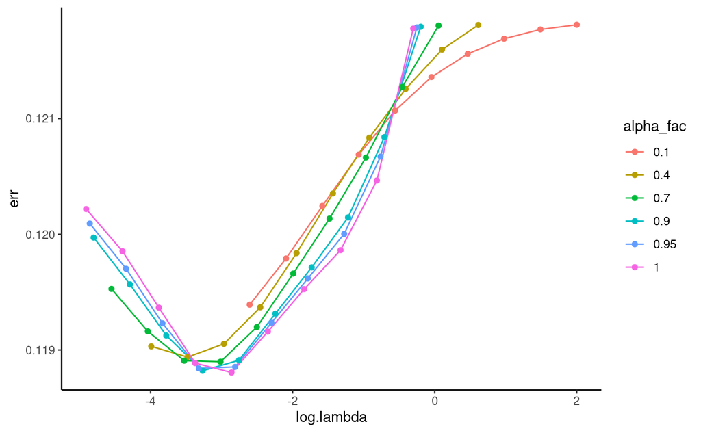

```r
model.results <- RunLinearModel(obj,
                                pert.col = "condition",
                                batch.col = "batch",
                                size.factor.col = "nCount_RNA",
                                mito.col = "percent.mt",
                                features.use = var.genes)
```

The `RunLinearModel` wrapper function returns a list including the model design matrix (x), response (y) which in this case is the normalized expression matrix, the ElasticNet model (model) and coefficients (coefs), and the model evaluation

```r
names(model.results)
```

```
 [1] "x"           "y"           "perts"       "train.cells" "test.cells"  "family"      "cv"          "model"       "coefs"       "evaluation"
```

The model coefficients represent the effect of each perturbation on gene expression

```r
print(dim(model.results$coefs))
```

```
[1] 4000   55
```

```r
print(model.results$coefs[1:5, 1:5])
```

```
                 ASCL1       ASCL3        ASCL4 ASCL5 ATF7
ACTC1     -0.050788886  0.03277820  0.010251644     0    0
LINC00458  0.019186178 -0.03264142 -0.029962373     0    0
NTS        0.194006751 -0.04438682  0.033525631     0    0
ACTA1     -0.031709582  0.02361890 -0.035877048     0    0
HAND1     -0.002172323  0.00314431 -0.006350222     0    0
```

The evaluation dataframe summarizes which perturbations the model was able to effectively predict by comparing the full model with a reduced model that has no perturbation information.

```r
head(model.results$evaluation)
```

|  | group | ncells | pearson | pearson_reduced | rel_performance |
| --- | --- | --- | --- | --- | --- |
| CRX | CRX | 14 | 0.11017560 | 0.003156525 | 5.125324 |
| ASCL1 | ASCL1 | 10 | 0.28549413 | 0.011736223 | 4.604421 |
| SNAI2 | SNAI2 | 21 | 0.26643933 | 0.029756867 | 3.162513 |
| OTX2 | OTX2 | 12 | 0.09821725 | 0.017363386 | 2.499928 |
| MYC | MYC | 10 | 0.11809818 | 0.024270781 | 2.282694 |
| MESP1 | MESP1 | 10 | 0.04933982 | 0.010516083 | 2.230155 |

The `rel_performance` metric describes the relative performance of the full vs reduced model for each perturbation. In this case, it’s specifically the log2 transform of the ratio of the full model pearson correlation with the reduced model pearson correlation. You can modify the evaluation metric in `RunLinearModel` by specifying the `eval.metric` parameter. Perturbations with a high `rel_performance` (>>1) are more likely to have a significant effect on expression.

We can pull out all the perturbations with `rel_performance > 2`.

```r
sig.perts <- subset(model.results$evaluation, rel_performance > 2)$group
sig.perts
```

```
[1] "CRX"   "ASCL1" "SNAI2" "OTX2"  "MYC"   "MESP1" "ERG"   "KLF4"  "CDX2"
```

And find the top upregulated genes (by coefficient magnitude) for each perturbation

```r
ngenes <- 4
top.sig.genes <- lapply(sig.perts, function(i) {
  top.up <- head(names(sort(model.results$coefs[,i], decreasing = T)), n = ngenes)
  # top.dn <- head(names(sort(model.results$coefs[,i], decreasing = F)), n = ngenes)
  # c(top.up, top.dn)
  top.up
})
top.sig.genes <- unique(unlist(top.sig.genes, F, F))
length(top.sig.genes)
```

```
[1] 33
```

We can create a new Seurat object with the model coefficients for visualization

```r
pert.coefs <- model.results$coefs[,colnames(model.results$coefs) %in% levels(as.factor(obj$condition))]
coef.obj <- CreateSeuratObject(pert.coefs)
coef.obj <- ScaleData(coef.obj, verbose = F)
coef.obj$pert <- as.factor(colnames(coef.obj))
coef.obj
```

```
An object of class Seurat
4000 features across 51 samples within 1 assay
Active assay: RNA (4000 features, 0 variable features)
```

We can plot the effects of the top perturbations

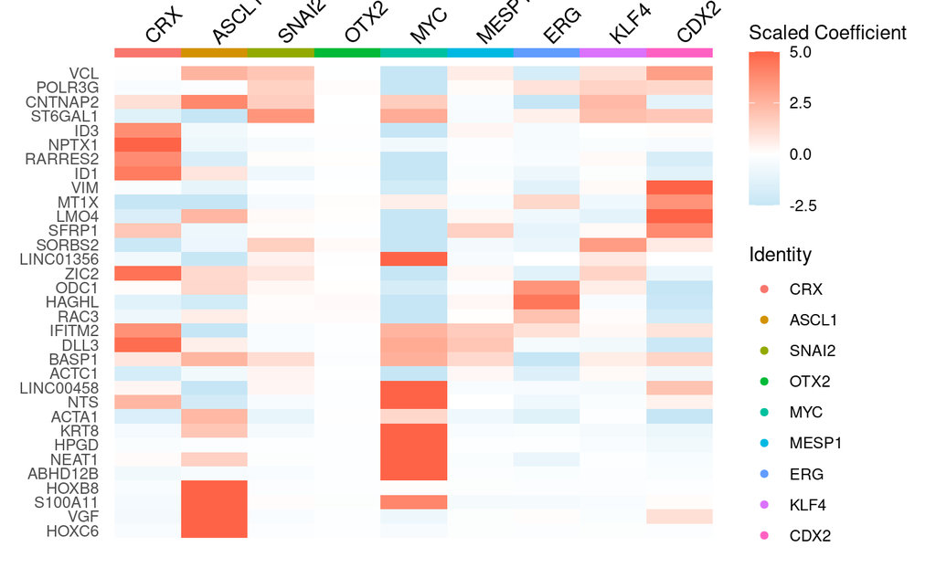

```r
coef.obj.top <- coef.obj[,sig.perts]
coef.obj.top$pert <- droplevels(coef.obj.top$pert)
levels(coef.obj.top$pert) <- sig.perts
DoHeatmap(coef.obj.top, features = top.sig.genes, group.by = "pert", size = 4, disp.max = 5, draw.lines = F) +
  scale_fill_gradient2(low = "skyblue", mid = "white", high = "tomato", midpoint = 0) +
  labs(fill='Scaled Coefficient')
```

We can also embed the perturbations using PCA

```r
coef.obj <- RunPCA(coef.obj, features = rownames(coef.obj))
```

[output not shown]

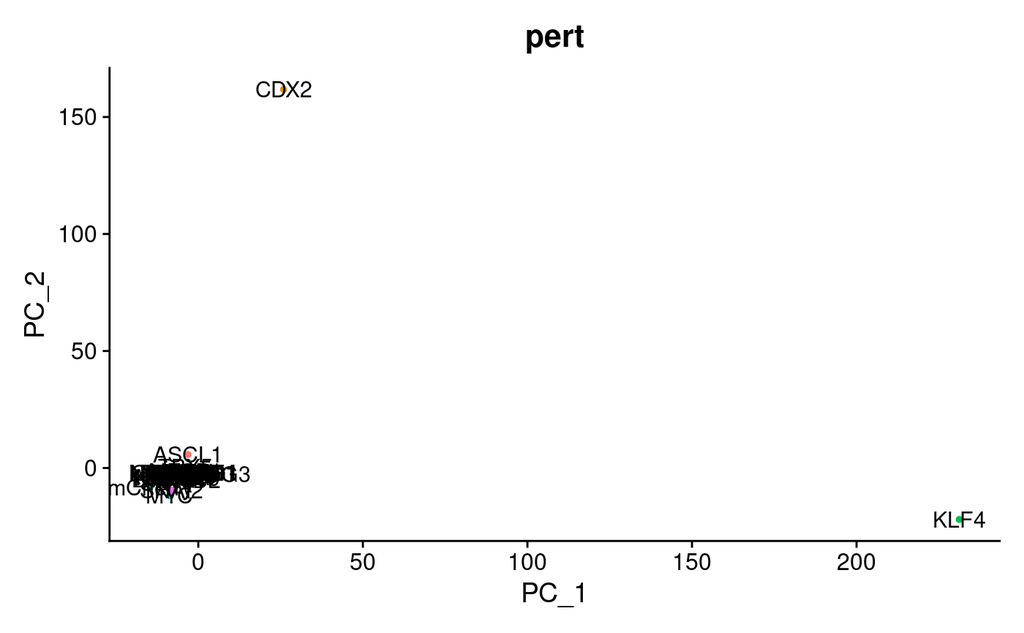

```r
PCAPlot(coef.obj, group.by = "pert", label = T) +
  theme(legend.position = "none")
```

We can also use a nonlinear embedding like UMAP

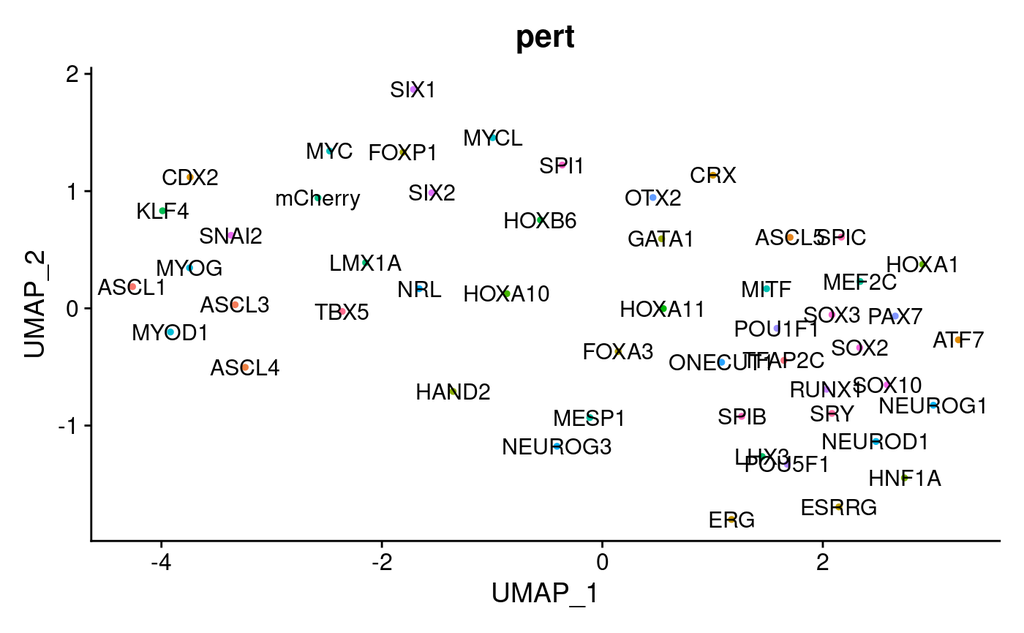

```r
coef.obj <- RunUMAP(coef.obj, dims = 1:15)
DimPlot(coef.obj, reduction = "umap", label = T, group.by = "pert") +
  theme(legend.position = "none")
```